# MD 6 Demo

2022-10-17

```r
library(tidyverse)
library(moderndive)
library(ggthemes)
library(patchwork)
library(broom)
library(ggrepel)
theme_set(theme_pander())
```

I just want a data frame with one class per professor. As I mentioned last time, I could have used `slice_sample(n = 1)` instead of what I do below with creating a random number. But unfortunately that would mean I have a different dataset (because the seed wouldn’t work the same). So I’ll stick with this.

```r
data(evals)

set.seed(1015)                            # for replicable results

d <- evals |>
  mutate(random = runif(nrow(evals))) |>  # as many random numbers as rows
  arrange(prof_ID, random) |>             # sort by random within groups
  group_by(prof_ID) |>                    # group it
  slice(1) |>                             # keep only one per prof
  select(prof_ID,                         # keep vars we need
         score,
         bty_avg,
         gender,
         ethnicity,
         language) |>
  rename(beauty = bty_avg,                # better name
         sex = gender) |>                 # what they measured
  ungroup()                               # just for completeness

glimpse(d)
```

```
## Rows: 94
## Columns: 6
## $ prof_ID   <int> 1, 2, 3, 4, 5, 6, 7, 8, 9, 10, 11, 12, 13, 14, 15, 16, 17, 1…
## $ score     <dbl> 4.1, 2.8, 4.1, 3.9, 4.8, 4.5, 4.4, 2.5, 4.5, 4.6, 3.7, 4.7, …
## $ beauty    <dbl> 5.000, 3.000, 3.333, 3.167, 7.333, 5.500, 4.167, 4.000, 4.66…
## $ sex       <fct> female, male, male, female, female, male, female, female, fe…
## $ ethnicity <fct> minority, not minority, not minority, not minority, not mino…
## $ language  <fct> english, english, english, english, english, english, englis…
```

Here’s the regression from last week.

```r
mod1 <- lm(score ~ beauty,
           data = d)

get_regression_table(mod1)
```

```
## # A tibble: 2 × 7
##   term      estimate std_error statistic p_value lower_ci upper_ci
##   <chr>        <dbl>     <dbl>     <dbl>   <dbl>    <dbl>    <dbl>
## 1 intercept    3.58      0.186     19.3     0       3.21     3.95
## 2 beauty       0.101     0.038      2.63    0.01    0.025    0.177
```

Let’s look at the predictions and residuals.

```r
mod1_preds <- get_regression_points(mod1)

head(mod1_preds)
```

```
## # A tibble: 6 × 5
##      ID score beauty score_hat residual
##   <int> <dbl>  <dbl>     <dbl>    <dbl>
## 1     1   4.1   5         4.08    0.018
## 2     2   2.8   3         3.88   -1.08
## 3     3   4.1   3.33      3.91    0.186
## 4     4   3.9   3.17      3.90    0.003
## 5     5   4.8   7.33      4.32    0.483
## 6     6   4.5   5.5       4.13    0.368
```

Here’s the regression line (blue).

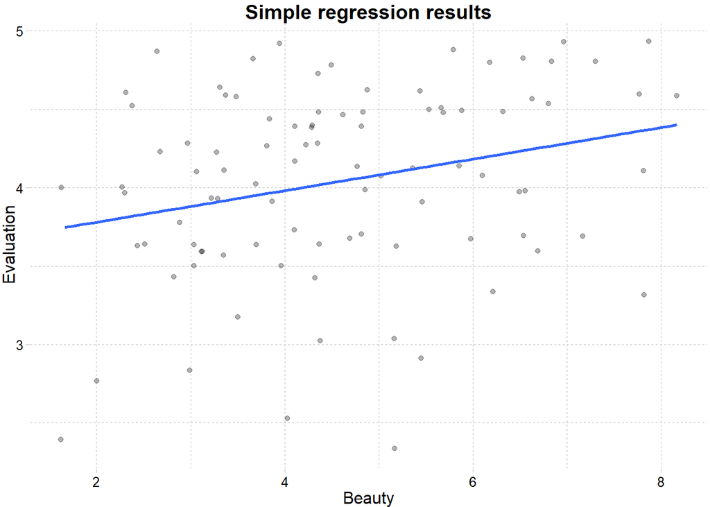

Here are the residuals.

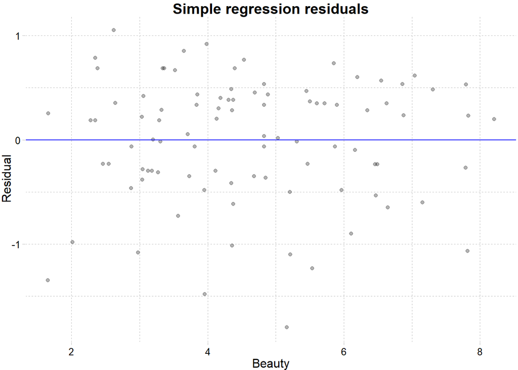

One way to quantify how well a predictor predicts the outcome is to use the **variance**. We’ve seen this already but let’s review. Here’s the formula. $\bar{y}$ is the mean of $y$.

$$var(y) = \frac{1}{n-1}\sum(y_i - \bar{y})^2$$
Since our outcome is evaluation score, we can just do that.

```r
var_y <- d |>
  pull(score) |>
  var()

var_y
```

```
## [1] 0.3673999
```

This is equivalent to the variance of the “residuals” when we just guess the mean value for every person!

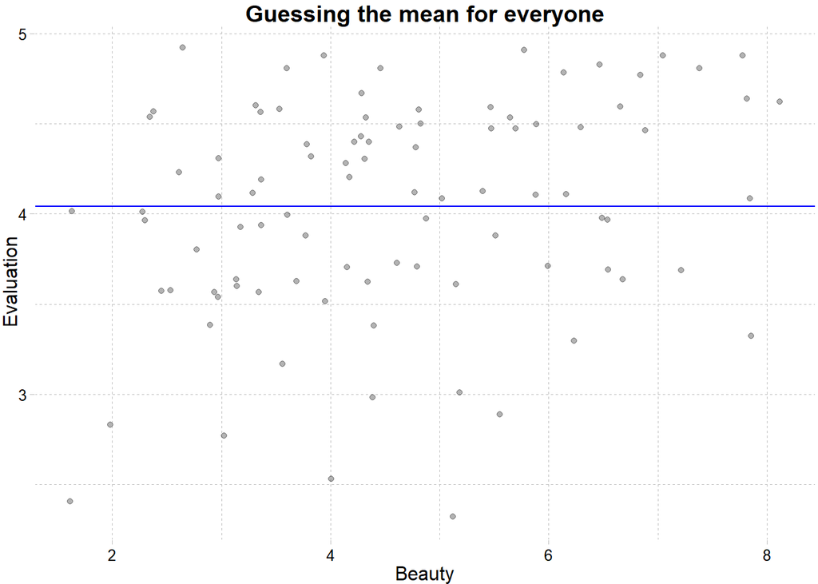

Adding `beauty` as a predictor improves our guess.

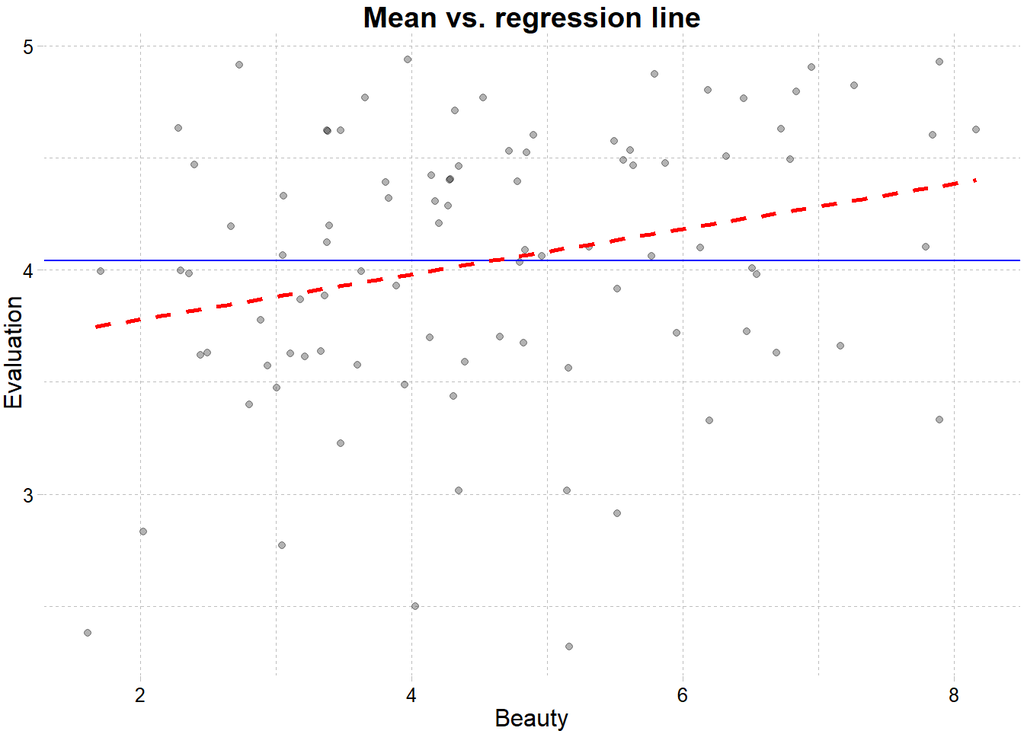

Now let’s see what the spread looks like if we look at the residuals from the regression line.

```r
var_yhat1 <- mod1_preds |>
  pull(residual) |>
  var()

var_yhat1
```

```
## [1] 0.3416584
```

If we take the ratio of these and subtract it from one, that gives us the $R^2$ or “proportion of variance explained” by beauty scores.

```r
1 - (var_yhat1 / var_y)
```

```
## [1] 0.07006395
```

It looks like “beauty” can account for about 7 percent of the variance in the evaluation scores.

In other words, if we try to guess instructors’ evaluation scores, our guesses will be 7 percent *less wrong* on average if we know the instructor’s beauty rating.

We can get this from `broom::glance()` or `moderndive::get_regression_summaries()` without doing it manually. The latter will be a more curated list of things you’ll need for this course.

```r
broom::glance(mod1)
```

```
## # A tibble: 1 × 12
##   r.squ…¹ adj.r…² sigma stati…³ p.value    df logLik   AIC   BIC devia…⁴ df.re…⁵
##     <dbl>   <dbl> <dbl>   <dbl>   <dbl> <dbl>  <dbl> <dbl> <dbl>   <dbl>   <int>
## 1  0.0701  0.0600 0.588    6.94 0.00990     1  -82.4  171.  178.    31.8      92
## # … with 1 more variable: nobs <int>, and abbreviated variable names
## #   ¹r.squared, ²adj.r.squared, ³statistic, ⁴deviance, ⁵df.residual
```

```r
moderndive::get_regression_summaries(mod1)
```

```
## # A tibble: 1 × 9
##   r_squared adj_r_squared   mse  rmse sigma statistic p_value    df  nobs
##       <dbl>         <dbl> <dbl> <dbl> <dbl>     <dbl>   <dbl> <dbl> <dbl>
## 1      0.07          0.06 0.338 0.581 0.588      6.94    0.01     1    94
```

Let’s try a different predictor. Let’s predict ratings with `sex`.

```r
mod2 <- lm(score ~ sex,
           data = d)

get_regression_table(mod2)
```

```
## # A tibble: 2 × 7
##   term      estimate std_error statistic p_value lower_ci upper_ci
##   <chr>        <dbl>     <dbl>     <dbl>   <dbl>    <dbl>    <dbl>
## 1 intercept    3.93      0.095     41.3    0        3.74     4.12
## 2 sex: male    0.198     0.125      1.58   0.117   -0.051    0.448
```

```r
get_regression_summaries(mod2)
```

```
## # A tibble: 1 × 9
##   r_squared adj_r_squared   mse  rmse sigma statistic p_value    df  nobs
##       <dbl>         <dbl> <dbl> <dbl> <dbl>     <dbl>   <dbl> <dbl> <dbl>
## 1     0.026         0.016 0.354 0.595 0.601      2.50   0.117     1    94
```

Looks like male instructors get slightly better evaluations but this only accounts for 2-3% of the variance.

In general, we are not going to want to do this with different variables one by one. We want to do **multiple regression**.

```r
mod3 <- lm(score ~ beauty + sex,
           data = d)

get_regression_table(mod3)
```

```
## # A tibble: 3 × 7
##   term      estimate std_error statistic p_value lower_ci upper_ci
##   <chr>        <dbl>     <dbl>     <dbl>   <dbl>    <dbl>    <dbl>
## 1 intercept    3.36      0.208     16.1    0        2.95     3.77
## 2 beauty       0.115     0.038      3.02   0.003    0.04     0.191
## 3 sex: male    0.264     0.122      2.16   0.033    0.021    0.506
```

Here’s what this model does.

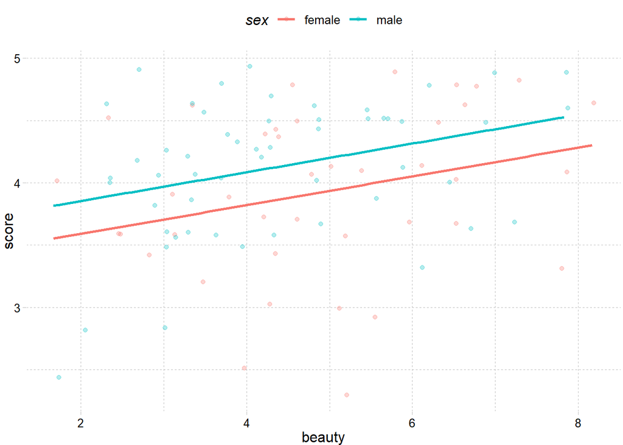

Here’s the formula:

$$\widehat{score}_i = 3.36 + .115(beauty_i) + .264(male_i)$$
We might instead prefer a model like this, which allows the relationship between beauty and evaluations to be different for male and female instructors.

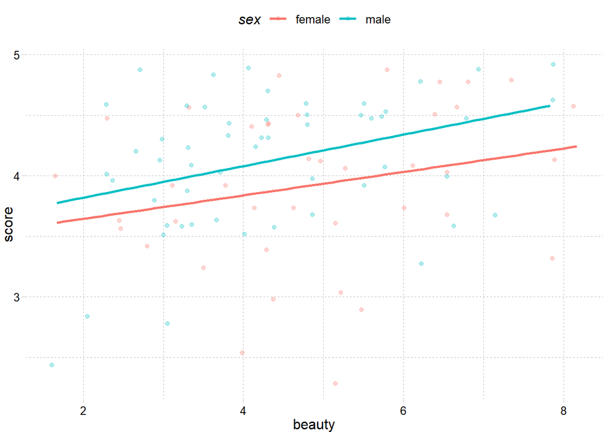

Here’s the syntax, results, and formula.

```r
mod4 <- lm(score ~ beauty + sex + beauty:sex,
           data = d)

get_regression_table(mod4)
```

```
## # A tibble: 4 × 7
##   term           estimate std_error statistic p_value lower_ci upper_ci
##   <chr>             <dbl>     <dbl>     <dbl>   <dbl>    <dbl>    <dbl>
## 1 intercept         3.45      0.296    11.7     0        2.86     4.04
## 2 beauty            0.097     0.057     1.69    0.094   -0.017    0.21
## 3 sex: male         0.108     0.38      0.284   0.777   -0.646    0.862
## 4 beauty:sexmale    0.033     0.077     0.434   0.665   -0.119    0.186
```

$$\widehat{score}_i = 3.45 + .097(beauty_i) + .108(male_i) + .033(beauty_i
\times male_i)$$
The slope for female instructors is .097. The slope for male instructors is .097 + .033 = .130.

```r
get_regression_summaries(mod3) # parallel
```

```
## # A tibble: 1 × 9
##   r_squared adj_r_squared   mse  rmse sigma statistic p_value    df  nobs
##       <dbl>         <dbl> <dbl> <dbl> <dbl>     <dbl>   <dbl> <dbl> <dbl>
## 1     0.115         0.096 0.322 0.567 0.576      5.94   0.004     2    94
```

```r
get_regression_summaries(mod4) # interactions
```

```
## # A tibble: 1 × 9
##   r_squared adj_r_squared   mse  rmse sigma statistic p_value    df  nobs
##       <dbl>         <dbl> <dbl> <dbl> <dbl>     <dbl>   <dbl> <dbl> <dbl>
## 1     0.117         0.088 0.321 0.566 0.579      3.99    0.01     3    94
```

The interaction model really doesn’t add much. It’s probably reasonable to assume the slopes are parallel.

## Example 2

Let’s look at which features of basketball team performance predict win percentage. We’re going to consider the following predictors:

- Effective FG percentage
- Turnover rate
- Offensive rebound percentage
- Free throw percentage

See the description [here](https://kenpom.com/blog/four-factors/) if you want more information.

```r
library(toRvik)

bf <- bart_factors(year = 2022)

bf <- bf |>
  mutate(winpct = (wins/games)*100) |>
  select(team, conf, winpct, off_efg, off_to, off_or, off_ftr)
```

Let’s look at some bivariate relationships.

**YOU WILL NEED GGally PACKAGE FOR THIS**

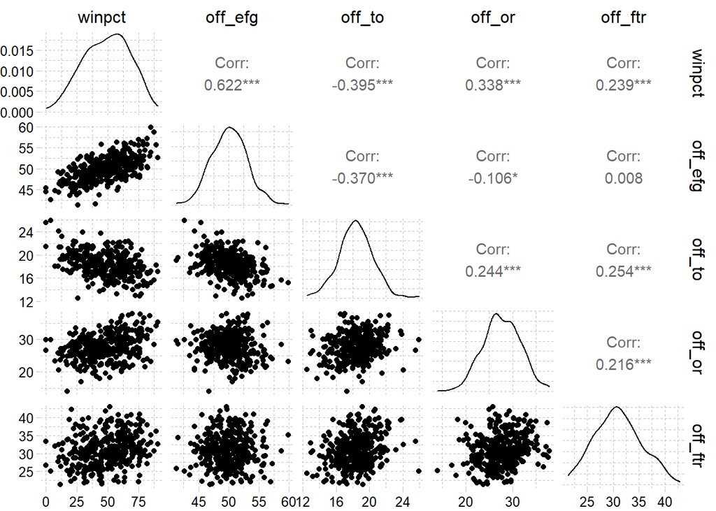

```r
library(GGally)

bf |>
  select(-team, -conf) |>
  ggpairs()
```

Since $R^2$ is the same as the correlation squared, we can use `cor()` to see the individual variance explained.

```r
bf |>
  select(-team, -conf) |>
  cor() |>
  as_tibble(rownames = "predictor") |>
  select(predictor:winpct) |>
  mutate(r2 = winpct^2)
```

```
## # A tibble: 5 × 3
##   predictor winpct     r2
##   <chr>      <dbl>  <dbl>
## 1 winpct     1     1
## 2 off_efg    0.622 0.386
## 3 off_to    -0.395 0.156
## 4 off_or     0.338 0.115
## 5 off_ftr    0.239 0.0570
```

Let’s how well we can do with all four factors.

```r
bmod1 <- lm(winpct ~ off_efg + off_to + off_or + off_ftr,
            data = bf)

get_regression_table(bmod1)
```

```
## # A tibble: 5 × 7
##   term      estimate std_error statistic p_value lower_ci upper_ci
##   <chr>        <dbl>     <dbl>     <dbl>   <dbl>    <dbl>    <dbl>
## 1 intercept -146.       13.8      -10.6        0 -173.     -119.
## 2 off_efg      3.39      0.209     16.2        0    2.98      3.80
## 3 off_to      -3.27      0.31     -10.5        0   -3.88     -2.66
## 4 off_or       2.02      0.148     13.7        0    1.73      2.31
## 5 off_ftr      0.967     0.133      7.29       0    0.706     1.23
```

```r
get_regression_summaries(bmod1)
```

```
## # A tibble: 1 × 9
##   r_squared adj_r_squared   mse  rmse sigma statistic p_value    df  nobs
##       <dbl>         <dbl> <dbl> <dbl> <dbl>     <dbl>   <dbl> <dbl> <dbl>
## 1     0.676         0.672  112.  10.6  10.7      184.       0     4   358
```

We can get the points to plot.

```r
bmod1_preds <- get_regression_points(bmod1,
                                     newdata = bf,
                                     ID = "team") |>
  left_join(select(bf, team, conf))
```

Here are the model predictions (x-axis) and the actual 2022 win percentages (y-axis).

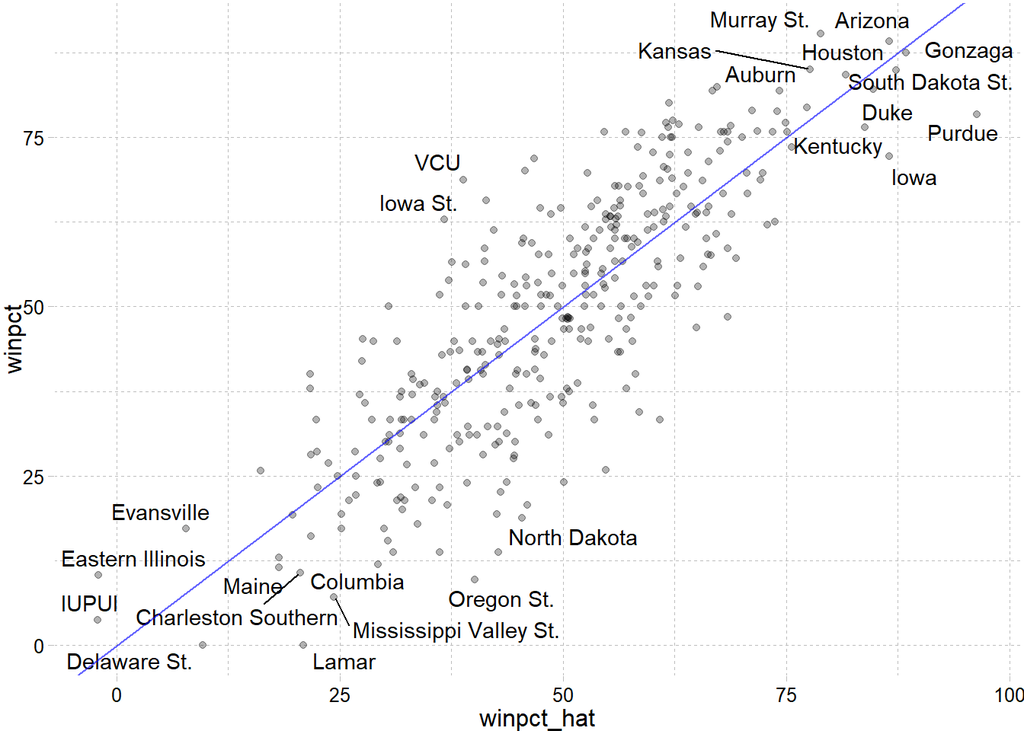

Or just showing these predictions among the ACC.

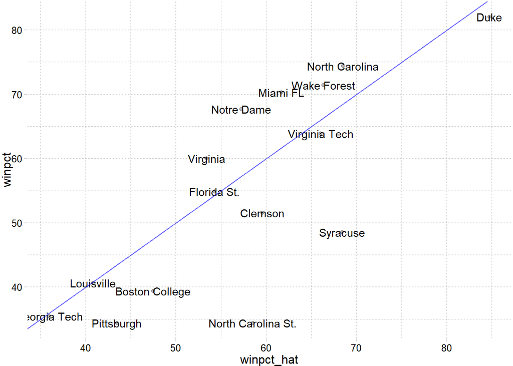

```r
ggplot(filter(bmod1_preds, conf == "ACC"),
       aes(x = winpct_hat,
           y = winpct,
           label = team)) +
  geom_point(alpha = .3) +
  geom_text() +
  geom_abline(intercept = 0,
              slope = 1,
              color = "blue",
              alpha = .6)
```